# Part II - Ford GoBike System Data Exploration

## by Ibrahima Diogoye Diouf

## Investigation Overview

In this investigation, I wanted to look at the time of the day and day of the week that most trips are taken, how long does the average trip take and see if the results of the ealier investigations depend on if a user is a subscriber or a customer.

## Dataset Overview

Upon proper data preparation for exploration, the dataset contains 183,412 rows and 12 columns:

start_time (datetime).

start_station_name (object)

bike_id(int)

end_station_name (object)

user_type (categorical) - Subscriber and Customer.

member_gender (categorical) - Male, Female and Other

bike_share_for_all_trip

Also, new columns were created:

day_of_week: to store week day number from start_time.

start_hour: to store hour number from start_time.

time_of_day: to store the time of the day from start_hour

duration_min: to store the duration in minutes.

distance :to store the distance

#### Most trips taken in terms of day of the week

The day of the week with the most trips is Thursday followed by Tuesday and wednesday.

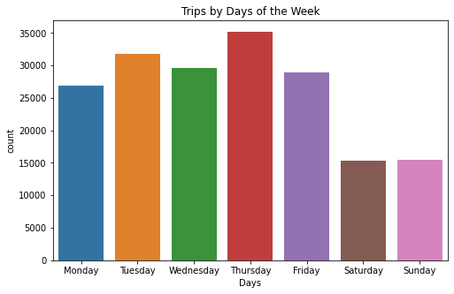

#### Most trips taken in terms of time of day

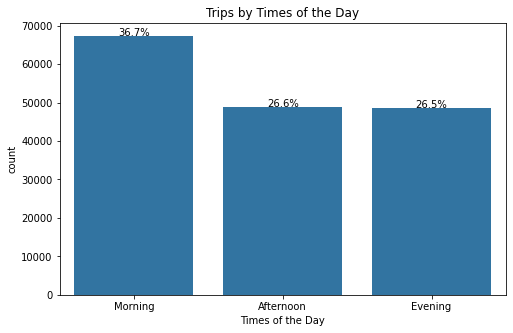

##### Distribution of Duration

Most rides took about (9-12) minutes. And very few rides lasted more than one hour (60 minutes). After standardizing by converted from second to minute and then plotted on a logarithmic scale, the distribution of trip duration takes on a unimodal shape.

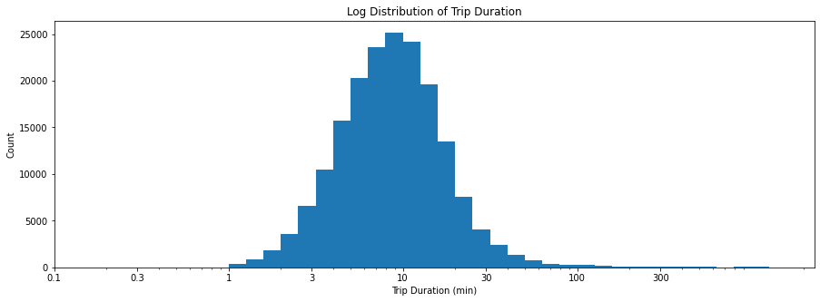

#### Does the time of the day that most trips are taken dependent on if a user is a subscriber or a customer?

The time of the day that most trips are taken (Afternoon and Morning) is slightly dependent on if a user is a subscriber or a customer. It was realized that Customers often start the trip in the afternoon where as Subscribers mostly start the trip in the morning.

[figure not shown]

### Does the day of the week that most trips are taken dependent on if a user is a subscriber or a customer?

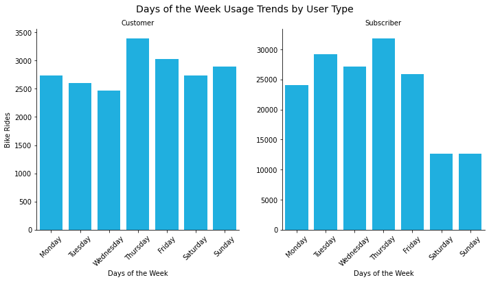

#### Does the average trip duration taken dependent on if a user is a subscriber or a customer?

The average trip duration IS highly dependent on if a user is a subscriber or just a customer. On average, Customers (24 minutes) have two times trip duration lenght of subscribers (10 minutes) i.e. Subscriber users tend to ride the bikes in lesser duration than customer users

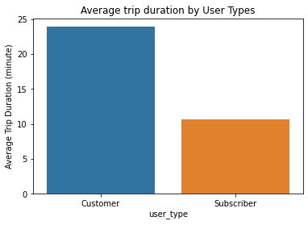

#### Rides by different user types

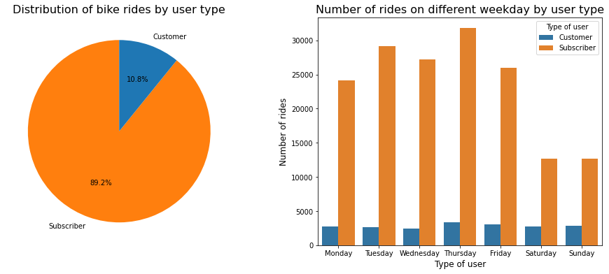

[output not shown]